# Algorithm Beginner Class 13 Lecture - Heap

2018/6/26

# Heap

Heap(堆),亦被稱為priority queue(優先隊列).

| - | Data Structure | Operating System |
| --- | --- | --- |
| Stack | LIFO | Call stack |
| Heap | Priority | Dynamic memory allocation |

## API (in Java)

Queue vs. PriorityQueue

Queue: FIFO,先進先出  
PriorityQueus: 無特殊說明時，誰小誰先出

```java
package laioffer;
import java.util.*;

public class Test {
  public static void main(String[] args) {
    Queue<Integer> pq = new PriorityQueue<>();
    //1) offer
    //2) poll
    //3) peak
    //4) size
    //5) isEmpty
    //6) remove
    pq.offer(7);
    pq.offer(3);
    pq.offer(5);

    System.out.println(pq.poll());  //3
    pq.offer(2);
    pq.offer(9);
    System.out.println(pq.peak());  //2
    System.out.println(pq.size());  //4
    pq.remove(9);
    System.out.println(pq.size());  //3
  }
}
```

```java
package laioffer;
import java.util.*;

public class Test {
  public static void main(String[] args) {
    Queue<String> pq = new PriorityQueue<>();
    //1) offer
    //2) poll
    //3) peak
    //4) size
    //5) isEmpty
    //6) remove
    pq.offer("da");
    pq.offer("ji");
    pq.offer("ch");

    System.out.println(pq.poll());  //"ch"
  }
}
```

```java
package laioffer;
import java.util.*;

public class Test {
  public static void main(String[] args) {
    NodeComparator myComp = new NodeComparator();
    Queue<Node> pq = new PriorityQueue<>(myComp);
    //1) offer
    //2) poll
    //3) peak
    //4) size
    //5) isEmpty
    //6) remove
    pq.offer(new Node(3));
    pq.offer(new Node(7));
    pq.offer(new Node(5));

    System.out.println(pq.poll());  //"ch"
  }
}

class Node {
  int value;
  public Node(int v) {
    value = v;
  }
}

class NodeComparator implements Comparator<Node> {
  @Override  //Java anotation?這個例子里可寫可不寫
  public int compare(Node o1, Node o2) {
    //if you want o1 to be before o2, return a negative number
    //if you want o1 to be after o2, return a positive number
    //if order of o1 and o2 are equal, return 0
    if (o1.value < o2.value) {
      return -1;
    }
    else if (o1.value > o2.value) {
      return 1;
    }
    else {
      return 0;
    }
  }
}
```

Reverse order:

```java
package laioffer;
import java.util.*;

public class Test {
  public static void main(String[] args) {
    Queue<Integer> pq = new PriorityQueue<>(Collections.reverseOrder());
    //1) offer
    //2) poll
    //3) peak
    //4) size
    //5) isEmpty
    //6) remove
    pq.offer(7);
    pq.offer(3);
    pq.offer(5);

    System.out.println(pq.poll());  //7
  }
}
```

## Internal

Binary Heap is a common type of Heap

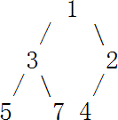

PQ滿足: Node個數相同時,滿二叉樹(complete binary tree)高度最小.

放到一維數組: 1 3 2 5 7 4

PQ滿足: 堆序性: parent <= children

peek: return root: O(1)

offer: offer 0: O(logn)

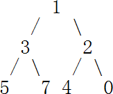

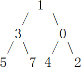

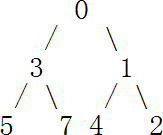

poll: O(logn)

永遠跟最小的swap

Java PriorityQueue支持的基本操作

1. offer(): 向堆中插入一個新元素,時間複雜度O($\log{n}$)
2. peek(): 獲取當前堆頂元素的值,時間複雜度O(1)
3. poll(): 刪除堆頂元素,時間複雜度O($\log{n}$)
4. Update a value,略
5. heapify: 使得一個unsorted array變成一個堆,時間複雜度O($n$).比一個一個放(時間複雜度O($n\log{n}$))快

## Q1. Find **smallest** k elements from an **unsorted** array of size n.

Solution(): Sort -> O($n\log{n}$)

[7, 4, 1, 9, 8, 15, 2, 3], k = 4

**Solution 1**: Max Heap: (每次拿最大出來)

初始  
leaf 7 4 1 9 root

>8, pool, offer  
leaf 7 4 1 8 root

>15 leaf 7 4 1 8 root

>2, pool, offer  
leaf 4 1 2 7 root

>3, pool, offer  
leaf 4 1 2 3 root

```java
class Solution {
  public void smallestK(int[] array, int k) {
    Queue<Integer> maxHeap = new PriorityQueue<>(Collections.reverseOrder());

    //Pretend we are using heapify
    //Time: O(k)
    for (int i = 0; i < k; i = i + 1) {
      maxHeap.offer(array[i]);
    }

    //Time: O(k+(n-k)logk)
    //if k << n, O(nlogk)
    //if k ~= n/2, O(nlogn)
    //if k ~= n, O(n)
    for (int i = k; i < array.length; i = i + 1) {
      if (array[i] < maxHeap.peak()) {
        maxHeap.poll();  //O(logk)
        maxHeap.offer(array[i]);  //O(logk)
      }
    }

    //remaining values in the maxHeap is the smallest k elements
  }
}
```

**Solution 2**: Min Heap

```java
class Solution {
  public void smallestK2(int[] array, int K) {
    List{Integer} list = new ArrayList<>();
    for (int x : array) {
      list.add(x);
    }
    //O(n)
    Queue<Integer> pq = new PriorityQueue<>(list);

    //O(klogn)
    for (int i = 0; i < K; i = i + 1) {
      System.out.println(pq.poll());
    }
  }
}
```

Time: O(n+klogn)  
if k << n: O(n)  
if k ~= n/2: O(nlogn)  
if k ~= n: O(nlogn)

| - | Sort | Max Heap | Min Heap |
| --- | --- | --- | --- |
| Time | O(nlogn) | O(k+(n-k)logk) | O(n+klogn) |
| (K << n) | O(nlogn) | O(nlogk) | O(n) |
| (k ~= n/2) | O(nlogn) | O(nlogn) | O(nlogn) |
| (k ~= n) | O(nlogn) | O(n) | O(nlogn) |
| Space | O(n) if mergesort | O(k) | O(n) |

**Solution 3**: QuickSelect O(n)

```java
class Solution {
  public List<Integer> quickSelect(int[] array, int k) {
    helper(array, k - 1, 0, array.length - 1);
    List<Integer> list = new ArrayList<>();
    for (int i = 0; i < k; i = i + 1) {
      list.add(array[i]);
    }
    return list;
  }
  private void helper(int[] array, int k, int left, int right) {
    if (left >= right) {
      return;
    }
    Random random = new Random();
    int pivotIndex = left + random.nextInt(right - left + 1);
    swap(array, pivotIndex, right);
    int l = left;
    int r = right - 1;
    while (l <= r) {
      if (array[l] < array[right]) {
        l = l + 1;
      }
      else {
        swap(array, l, r);
        r = r - 1;
      }
    }
    swap(array, l, right);
    if (k == l) {
      return;
    }
    else if (k < l) {
      helper(array, k, left, l - 1);
    }
    else {
      helper(array, k, l + 1, right);
    }
  }
  private void swap(int[] array, int a, int b) {
    int temp = array[a];
    array[a] = array[b];
    array[b] = temp;
  }
}
```